# Sobre-educación

# Paquetes requeridos

```r
library(tidyverse)
```

```r
# paleta de colores p. 422
library(RColorBrewer)
# letter value plot p. 99 (inglés)
library(lvplot)
# calcular la moda
library(DescTools)
# coeficiente de asimetría
library(moments)
library(EnvStats)
# # 1. vivienda
# viv <- read_csv(
#   "enoet22025/ENOE_VIVT225.csv",
#   col_types = cols(.default = col_character())
# )

# # 2. hogar
# hog <- read_csv(
#   "enoet22025/ENOE_HOGT225.csv",
#   col_types = cols(.default = col_character())
# )

# 3. sociodemográfica
sdem <- read_csv(
  "enoet22025/ENOE_SDEMT225.csv",
  col_types = cols(.default = col_character())
)

# 4. ocupación y empleo I
coe1 <- read_csv(
  "enoet22025/ENOE_COE1T225.csv",
  col_types = cols(.default = col_character())
)

# 5. ocupación y empleo II
coe2 <- read_csv(
  "enoet22025/ENOE_COE2T225.csv",
  col_types = cols(.default = col_character())
)

# segmentación
sdem<- sdem %>% mutate(
  # edad
  eda = as.integer(eda),
  # ponderador trimestral
  fac_tri = as.double(fac_tri),
  # ingreso mensual
  ingocup = as.double(ingocup),
  # promedio de ingreso por hora
  ing_x_hrs = as.double(ing_x_hrs)
)

# grupos de edad
sdem <- sdem %>%
  mutate(
    edad_7g = case_when(
      between(eda, 0, 14) ~ "1",
      between(eda, 15, 24) ~ "2",
      between(eda, 25, 34) ~ "3",
      between(eda, 35, 44) ~ "4",
      between(eda, 45, 54) ~ "5",
      between(eda, 55, 64) ~ "6",
      between(eda, 65, 97) ~ "7",
      # edad no especificada mayores a 12
      eda == "98" ~ "98",
      # edad no especificada menores a 12
      eda == "99" ~ "99",
      # NA sin comillas para valores faltantes
      TRUE ~ NA
    )
  )

# carreras universitarias
sdem <- sdem %>%
  mutate(
    carrera1 = if_else(str_length(cs_p14_c) == 5, str_c("0", cs_p14_c), cs_p14_c),
    carrera2 = if_else(str_length(cs_p14_c) == 5, str_c("0", cs_p14_c), cs_p14_c),
    carrera3 = if_else(str_length(cs_p14_c) == 5, str_c("0", cs_p14_c), cs_p14_c)
  ) %>%
  separate(
    carrera1,
    # campo amplio
    into = c("carrera1", "res"),
    sep = 2
  ) %>%
  separate(
    carrera2,
    # campo específico
    into = c("carrera2", "res"),
    sep = 3
  ) %>%
  separate(
    carrera3,
    # campo detallado
    into = c("carrera3", "res"),
    sep = 4
  ) %>%
  select(-res)

# grupos ocupacionales
coe1 <- coe1 %>%
  mutate(
    ocupacion1 = p3,
    ocupacion2 = p3
  ) %>%
  separate(
    ocupacion1,
    into = c("ocupacion1", "res"),
    sep = 1
  ) %>%
  separate(
    ocupacion2,
    into = c("ocupacion2", "res"),
    sep = 2
  ) %>%
  select(-res)

# población total
pob_total <- sdem %>%
  filter(
    r_def == "0",
    # es igual a (c_res == "1" | c_res == "3")
    c_res != "2"
  )

# población de 12 años y más
pob_12ymas <- sdem %>%
  filter(
  r_def == "0",
  c_res != "2",
  between(eda, 12, 98)
  )

# población de 15 años y más
pob_15ymas <- sdem %>%
  filter(
    r_def == "0",
    c_res != "2",
    between(eda, 15, 98)
  )

# unión de sdem y coe
completo <- pob_12ymas %>%
  full_join(coe1, by = c("tipo", "mes_cal", "ent", "con", "v_sel", "n_hog", "h_mud", "n_ren")) %>%
  full_join(coe2, by = c("tipo", "mes_cal", "ent", "con", "v_sel", "n_hog", "h_mud", "n_ren"))

# profesionistas
profesionistas <- completo %>%
  filter(
    cs_p13_1 == "7" | cs_p13_1 == "8" | cs_p13_1 == "9"
  )

# jovenes
jovenes <- completo %>%
  filter(edad_7g == "3")
```

# Introducción

Este documento es la continuación de:

1. C:/Prog/tesis/1_Primeros_pasos.Rmd
2. C:/Prog/tesis/INEGI-2023_Conociendo-ENOE.Rmd
3. C:/Prog/tesis/2_Analisis_exploratorio_datos1.Rmd
4. C:/Prog/tesis/3_Limpieza_datos.Rmd
5. C:/Prog/tesis/4_Panorama_jovenes.Rmd

Se tratará de construir las variables asociadas a la sobre-educación.

Recordemos que existen tres métodos para determinar la sobre-educación.

1. Objetivo:
2. Subjetivo: formal y real,
3. Estadístico:

En primer lugar, el método objetivo se utilizó en los trabajos seminales del tema: Rumberger (1981), Rumberger (1987), Kiker et al. (1997), Zamudio (1997), etc. En la actualidad, es el método que emplea la Organización Internacional del Trabajo (ILO, por sus siglas en inglés) para construir sus indicadores relacionados al desajuste educativo (*education mismatch*), por ejemplo véase OECD (2019), ILO (2021), ILO (2024) y la página web del indicador de desajuste educativo (EMI, por sus siglas en inglés): [Education and Mismatch Indicators (EMI database)](https://ilostat.ilo.org/methods/concepts-and-definitions/description-education-and-mismatch-indicators)

En cuanto al subjetivo, las lecturas realizadas de Dolton and Silles (2001), Di Pietro and Urwin (2006) y Capsada-Munsech (2017) permiten identificar dos tipos:

- Formal: se le pregunta al trabajador la educación formal requerida para *ingresar* al puesto de trabajo
- Real: se le pregunta al trabajador la educación formal requerida para *realizar* las actividades del puesto de trabajo

Consideramos que el método subjetivo formal identifica la sobre-educación (*over-education*) mientras que el real permite identificar el problema de la sobre-habilidad (*overskilled*) que padecen ciertos egresados de distintos países.

Por su parte, existen tres tipos de método estadístico:

- Media +/- 1 desviación estándar: Verdugo and Verdugo (1989)
- Moda: Kiker et al. (1997)
- Mediana: Zamudio and Islas (1999)

Cabe la pena señalar que García-Montalvo and Peiró (2009), Mehta et al. (2011) y Quinn and Rubb (2006) señala otros tipos de métodos para determinar la sobre-educación. Véase Hartog (2000), Groot and Maassen van den Brink (2000), Rubb (2003), McGuinness (2006), García-Montalvo and Peiró (2009) y Capsada-Munsech (2017) para ver los alcances y limitantes de cada método así como la discusión que existe al respecto.

# Incidencia

En la presente investigación se utilizará el método estadístico, en específico, el método de la moda o mediana ¿por qué? además de las ventajas presentadas en Kiker et al. (1997), refleja el resultado de una asignación (Hartog (2000)) para ser más exactos una asignación no eficiente (Sattinger (1993)). Cabe señalar que la moda o mediana se construye mediante los grupos ocupacionales.

## Moda

### ¿Existe una función de la moda?

No existe una función nativa que calcule la moda, como función proxy está `table`, por lo que hay que instalar el paquete `DescTools`.

```r
# a <- system.file(package = "DescTools")
# if (a == "") {
#   install.packages("DescTools")
# } else {
#   library(DescTools)
# }
# system.file(package = "DescTools")
# install.packages("DescTools")
# library(DescTools)
```

Vamos a probar la función `Mode`.

```r
df <- tribble(
  ~x, ~y, ~z,
  #--|-----|---
  "A", "5", "200",
  "A", "5", "100",
  "A", "5", "300",
  "B", "7", "150",
  "B", "8", "250",
  "C", "1", "100"
)

DescTools::Mode(df$x)
```

```
## [1] "A"
## attr(,"freq")
## [1] 3
```

La función `Mode` muestra tres valores: el valor que más se repite (la moda), un atributo y el número de veces que se repite.

```r
base::table(df$x)
```

```
##
## A B C
## 3 2 1
```

Por su parte, la función `table` muestra los valores y el número de veces que se repite.

Cabe señalar que puede calcularse la moda con las funciones de `tidyverse`.

```r
df %>%
  count(x, sort = TRUE)
```

| x | n |
| --- | --- |
| A | 3 |
| B | 2 |
| C | 1 |

La cuestión es: ¿cómo asignarle la moda a una variable (columna) dentro de mutate? Quizá con la función `max`

```r
df %>%
  count(x, sort = TRUE) %>%
  mutate(mode = max(n))
```

| x | n | mode |
| --- | --- | --- |
| A | 3 | 3 |
| B | 2 | 3 |
| C | 1 | 3 |

Como se observa, se creo una variable que contiene la moda de las observaciones. Veamos un ejemplo práctico.

```r
library(datos)

datos::millas
```

| fabricante | modelo | cilindrada | anio | cilindros | transmision | traccion | ciudad | autopista | combustible | clase |
| --- | --- | --- | --- | --- | --- | --- | --- | --- | --- | --- |
| audi | a4 | 1.8 | 1999 | 4 | auto(l5) | d | 18 | 29 | p | compacto |
| audi | a4 | 1.8 | 1999 | 4 | manual(m5) | d | 21 | 29 | p | compacto |
| audi | a4 | 2.0 | 2008 | 4 | manual(m6) | d | 20 | 31 | p | compacto |
| audi | a4 | 2.0 | 2008 | 4 | auto(av) | d | 21 | 30 | p | compacto |
| audi | a4 | 2.8 | 1999 | 6 | auto(l5) | d | 16 | 26 | p | compacto |
| audi | a4 | 2.8 | 1999 | 6 | manual(m5) | d | 18 | 26 | p | compacto |
| audi | a4 | 3.1 | 2008 | 6 | auto(av) | d | 18 | 27 | p | compacto |
| audi | a4 quattro | 1.8 | 1999 | 4 | manual(m5) | 4 | 18 | 26 | p | compacto |
| audi | a4 quattro | 1.8 | 1999 | 4 | auto(l5) | 4 | 16 | 25 | p | compacto |
| audi | a4 quattro | 2.0 | 2008 | 4 | manual(m6) | 4 | 20 | 28 | p | compacto |

[output cut: 224 more lines]

¿Existen valores distintos de `fabricante`?

```r
datos::millas %>%
  count(fabricante)
```

| fabricante | n |
| --- | --- |
| audi | 18 |
| chevrolet | 19 |
| dodge | 37 |
| ford | 25 |
| honda | 9 |
| hyundai | 14 |
| jeep | 8 |
| land rover | 4 |
| lincoln | 3 |
| mercury | 4 |

[output cut: 5 more lines]

Calculemos la moda con las tres funciones:

1. `Mode`

```r
DescTools::Mode(millas$fabricante)
```

```
## [1] "dodge"
## attr(,"freq")
## [1] 37
```

2. `table`

```r
base::table(millas$fabricante)
```

```
##
##       audi  chevrolet      dodge       ford      honda    hyundai       jeep
##         18         19         37         25          9         14          8
## land rover    lincoln    mercury     nissan    pontiac     subaru     toyota
##          4          3          4         13          5         14         34
## volkswagen
##         27
```

3. `count` + `mutate`

```r
datos::millas %>%
  count(fabricante) %>%
  mutate(mode = max(n))
```

| fabricante | n | mode |
| --- | --- | --- |
| audi | 18 | 37 |
| chevrolet | 19 | 37 |
| dodge | 37 | 37 |
| ford | 25 | 37 |
| honda | 9 | 37 |
| hyundai | 14 | 37 |
| jeep | 8 | 37 |
| land rover | 4 | 37 |
| lincoln | 3 | 37 |
| mercury | 4 | 37 |

[output cut: 5 more lines]

¿Si quiero conocer la observación que más se repite?

```r
datos::millas %>%
  count(fabricante) %>%
  filter(n == max(n))
```

| fabricante | n |
| --- | --- |
| dodge | 37 |

Ahora, utilicemos una de las tablas creadas con datos de la ENOE: `jovenes`

1. `DescTools`

```r
DescTools::Mode(jovenes$cs_p13_1)
```

```
## [1] "7"
## attr(,"freq")
## [1] 20531
```

2. `table`

```r
base::table(jovenes$cs_p13_1)
```

```
##
##     0     1     2     3     4     6     7     8     9    99
##   608    16  4102 15083 16801   881 20531  1081    98    72
```

3. `count` + `mutate`

```r
jovenes %>%
  count(cs_p13_1) %>%
  filter(n == max(n))
```

| cs_p13_1 | n |
| --- | --- |
| 7 | 20531 |

Para seguir con el “universo” de `tidyverse` trabajaremos con la tercera opción.

### Años requeridos

La incidencia se debe construir dentro de cada grupo ocupacional, para fines de ejemplo se trabajará con la tabla `jovenes`.

```r
jovenes %>%
  count(ocupacion1, cs_p13_1) %>%
  group_by(ocupacion1) %>%
  filter(n == max(n))
```

| ocupacion1 | cs_p13_1 | n |
| --- | --- | --- |
| 1 | 7 | 1073 |
| 2 | 7 | 7595 |
| 3 | 7 | 2311 |
| 4 | 4 | 2289 |
| 5 | 4 | 1731 |
| 6 | 3 | 490 |
| 7 | 3 | 1505 |
| 8 | 4 | 2183 |
| 9 | 3 | 2904 |
| NA | 3 | 4558 |

Pero, debe trabajarse las ponderaciones trimestrales.

```r
jovenes %>%
  group_by(ocupacion1, cs_p13_1) %>%
  summarise(
    tot = sum(fac_tri.x)
  ) %>%
  filter(tot == max(tot))
```

| ocupacion1 | cs_p13_1 | tot |
| --- | --- | --- |
| 1 | 7 | 379397 |
| 2 | 7 | 2207696 |
| 3 | 7 | 682351 |
| 4 | 4 | 715566 |
| 5 | 4 | 501595 |
| 6 | 3 | 178001 |
| 7 | 3 | 489174 |
| 8 | 4 | 651938 |
| 9 | 3 | 971710 |
| NA | 3 | 1497514 |

De forma gráfica,

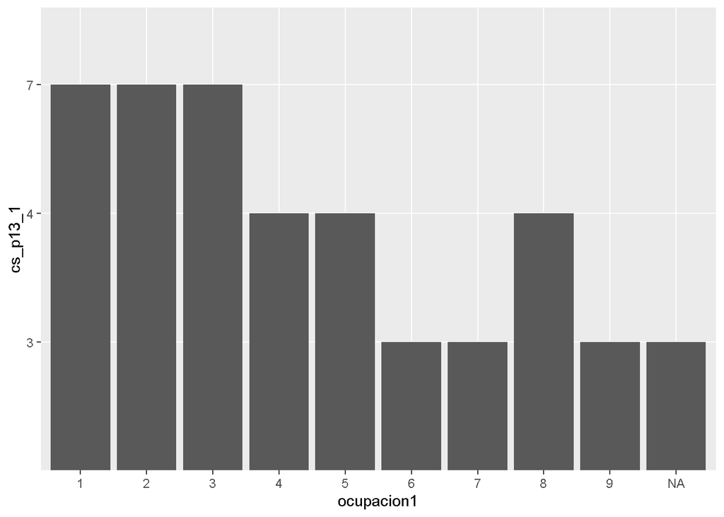

```r
jovenes %>%
  group_by(ocupacion1, cs_p13_1) %>%
  summarise(
    tot = sum(fac_tri.x)
  ) %>%
  filter(tot == max(tot)) %>%
  ggplot(aes(ocupacion1, cs_p13_1)) +
  geom_col()
```

En las ocupaciones de funcionarios, profesionistas y auxiliares en actividades administrativas la educación requerida es a nivel universitario, mientras que en los demás la educación requerida es menor hasta nivel secundaria.

Otra manera

```r
jovenes %>%
  group_by(ocupacion1, cs_p13_1) %>%
  summarise(
    tot = sum(fac_tri.x)
  ) %>%
  mutate(
    mode = cs_p13_1[tot == max(tot)]
  ) %>%
  count(ocupacion1, mode) %>%
  select(-n)
```

| ocupacion1 | mode |
| --- | --- |
| 1 | 7 |
| 2 | 7 |
| 3 | 7 |
| 4 | 4 |
| 5 | 4 |
| 6 | 3 |
| 7 | 3 |
| 8 | 4 |
| 9 | 3 |
| NA | 3 |

Es decir, se puede añadir tanto el conteo como la observación de la moda. Ahora bien, ¿cómo añadir los años requeridos a cada observación de la muestra? Veamos un ejemplo.

```r
df <- tribble(
  ~x, ~y, ~z,
  #--|-----|---
  "A", "5", "200",
  "A", "5", "100",
  "A", "5", "300",
  "B", "7", "150",
  "B", "8", "250",
  "C", "1", "100"
)

df %>%
  group_by(x, y) %>%
  summarise(
    n = n()
  ) %>%
  mutate(mode = y[n == max(n)])
```

[output not shown]

| x | y | n | mode |
| --- | --- | --- | --- |
| A | 5 | 3 | 5 |
| B | 7 | 1 | 7 |
| B | 8 | 1 | 8 |
| C | 1 | 1 | 1 |

¿Qué ocurre cuando `n == 1`? Se dice que no hay moda ¿cómo señalarlo en el código?

```r
df %>%
  group_by(x, y) %>%
  summarise(
    n = n()
  ) %>%
  mutate(
    mode = if_else(n > 1 & n == max(n), y, "NA")
  )
```

[output not shown]

| x | y | n | mode |
| --- | --- | --- | --- |
| A | 5 | 3 | 5 |
| B | 7 | 1 | NA |
| B | 8 | 1 | NA |
| C | 1 | 1 | NA |

Intentaremos añadir la variable a la tabla original. Lo único que se me ocurre es unir tablas.

```r
df_mode <- df %>%
  group_by(x, y) %>%
  summarise(n = n()) %>%
  mutate(
    y_mode = if_else(n > 1 & n == max(n), y, "NA")
  ) %>%
  select(-(y:n))
```

[output not shown]

```r
left_join(df, df_mode, by = "x")
```

| x | y | z | y_mode |
| --- | --- | --- | --- |
| A | 5 | 200 | 5 |
| A | 5 | 100 | 5 |
| A | 5 | 300 | 5 |
| B | 7 | 150 | NA |
| B | 7 | 150 | NA |
| B | 8 | 250 | NA |
| B | 8 | 250 | NA |
| C | 1 | 100 | NA |

Veamos otro ejemplo con `millas`.

```r
millas_mode <- millas %>%
  group_by(fabricante, traccion) %>%
  summarise(
    n = n()
  ) %>%
  filter(n == max(n)) %>%
  mutate(traccion_mode = traccion) %>%
  select(-(traccion:n))
left_join(millas, millas_mode, by = "fabricante")
```

| fabricante | modelo | cilindrada | anio | cilindros | transmision | traccion | ciudad | autopista | combustible | clase | traccion_mode |
| --- | --- | --- | --- | --- | --- | --- | --- | --- | --- | --- | --- |
| audi | a4 | 1.8 | 1999 | 4 | auto(l5) | d | 18 | 29 | p | compacto | 4 |
| audi | a4 | 1.8 | 1999 | 4 | manual(m5) | d | 21 | 29 | p | compacto | 4 |
| audi | a4 | 2.0 | 2008 | 4 | manual(m6) | d | 20 | 31 | p | compacto | 4 |
| audi | a4 | 2.0 | 2008 | 4 | auto(av) | d | 21 | 30 | p | compacto | 4 |
| audi | a4 | 2.8 | 1999 | 6 | auto(l5) | d | 16 | 26 | p | compacto | 4 |
| audi | a4 | 2.8 | 1999 | 6 | manual(m5) | d | 18 | 26 | p | compacto | 4 |
| audi | a4 | 3.1 | 2008 | 6 | auto(av) | d | 18 | 27 | p | compacto | 4 |
| audi | a4 quattro | 1.8 | 1999 | 4 | manual(m5) | 4 | 18 | 26 | p | compacto | 4 |
| audi | a4 quattro | 1.8 | 1999 | 4 | auto(l5) | 4 | 16 | 25 | p | compacto | 4 |
| audi | a4 quattro | 2.0 | 2008 | 4 | manual(m6) | 4 | 20 | 28 | p | compacto | 4 |

[output cut: 224 more lines]

De acuerdo a la nota de Wickham and Grolemund (2017) cap 3, Transformaciones agrupadas y filtros se recomienda filtrar después de agrupar si y sólo si se ha aplicado una función de resumir: “deberías usar filter() después de resumir, o usar group_by() + filter() directamente sin perder el contexto de grupo”, véase las notas de Notion para más información. Entonces, se podría decir que estamos aplicando correctamente el filtro ya que se realiza después de resumir.

Sigamos con la tabla `jovenes`

```r
jovenes_sr <- jovenes %>%
  group_by(ocupacion1, cs_p13_1) %>%
  summarise(
    tot = sum(fac_tri.x)
  ) %>%
  filter(tot == max(tot)) %>%
  mutate(s_r = cs_p13_1) %>%
  select(-(cs_p13_1:tot))
# definamos nueva tabla
jovenes2 <- left_join(jovenes, jovenes_sr, by = "ocupacion1")
```

### Incidencia

Intentemos determinar la incidencia de la sobre-educación

```r
jov_edu_mismatch <- jovenes2 %>%
  mutate(
    cs_p13_1 = as.integer(cs_p13_1),
    s_r = as.integer(s_r),
    edu_mismatch = case_when(
      cs_p13_1 > s_r ~ "over",
      cs_p13_1 < s_r ~ "under",
      TRUE ~ "required"
    ),
    s_o = if_else(cs_p13_1 > s_r, cs_p13_1 - s_r, 0),
    s_u = if_else(s_r > cs_p13_1, s_r - cs_p13_1, 0),
  )

jov_edu_mismatch %>%
  count(edu_mismatch) %>%
  mutate(prop = n / sum(n))
```

| edu_mismatch | n | prop |
| --- | --- | --- |
| over | 19123 | 0.3226258 |
| required | 26639 | 0.4494289 |
| under | 13511 | 0.2279453 |

El 32% de los jóvenes están sobre-educados, mientras que el 45% está en una ocupación que requiere la educación que posee y el 23% está infra-educado, es decir, el puesto de trabajo requiere una mayor educación a la que tiene el individuo.

Lo que todavía no sé es si crear una variable (columna) que englobe los tres tipos de desajuste, como en el ejemplo anterior, o crear una variable para cada tipo de desajuste. De inicio, es una variable categórica en ese sentido debe estar en una sola variable.

#### Por grupos ocupacionales

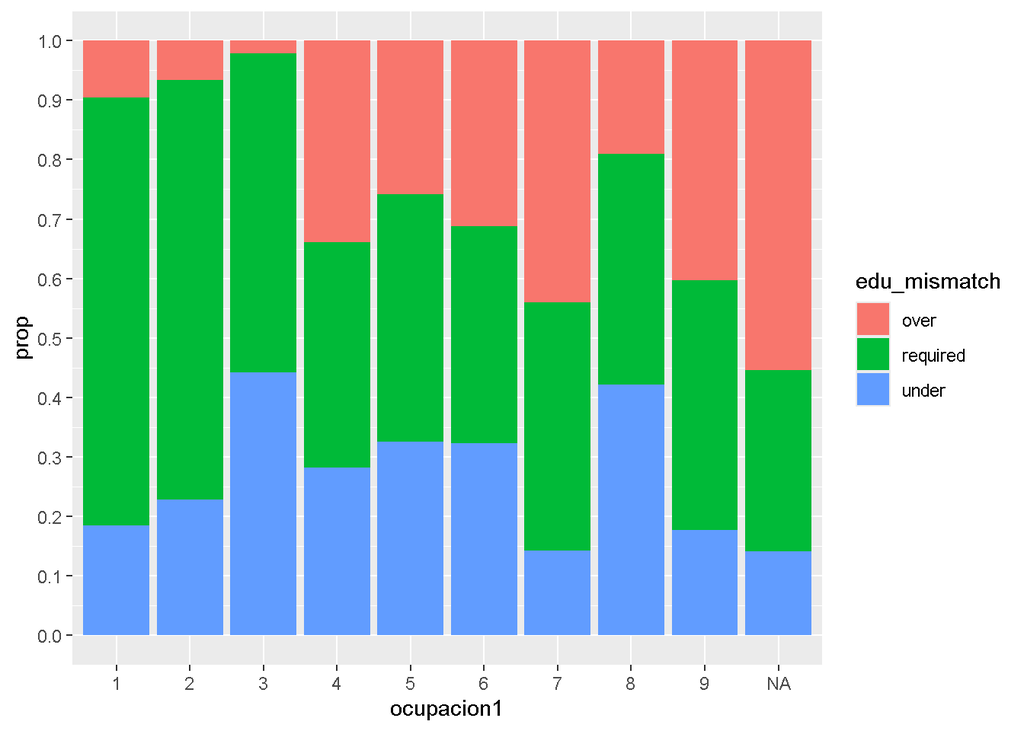

```r
jov_edu_mismatch %>%
  group_by(ocupacion1, edu_mismatch) %>%
  summarise(
    tot = sum(fac_tri.x)
  ) %>%
  mutate(prop = tot / sum(tot)) %>%
  ggplot(aes(ocupacion1, prop, fill = edu_mismatch)) +
  geom_col() +
  scale_y_continuous(
    breaks = seq(0, 1, by = 0.1)
  )
```

En los grupos ocupacionales “Trabajadores artesanales, en la construcción y otros oficios” (valor 7) y “Trabajadores en actividades elementales y de apoyo” (valor 9), se observa que alrededor del 40% de jóvenes de 25 a 34 años están sobre-educados.

#### Por carreras universitarias

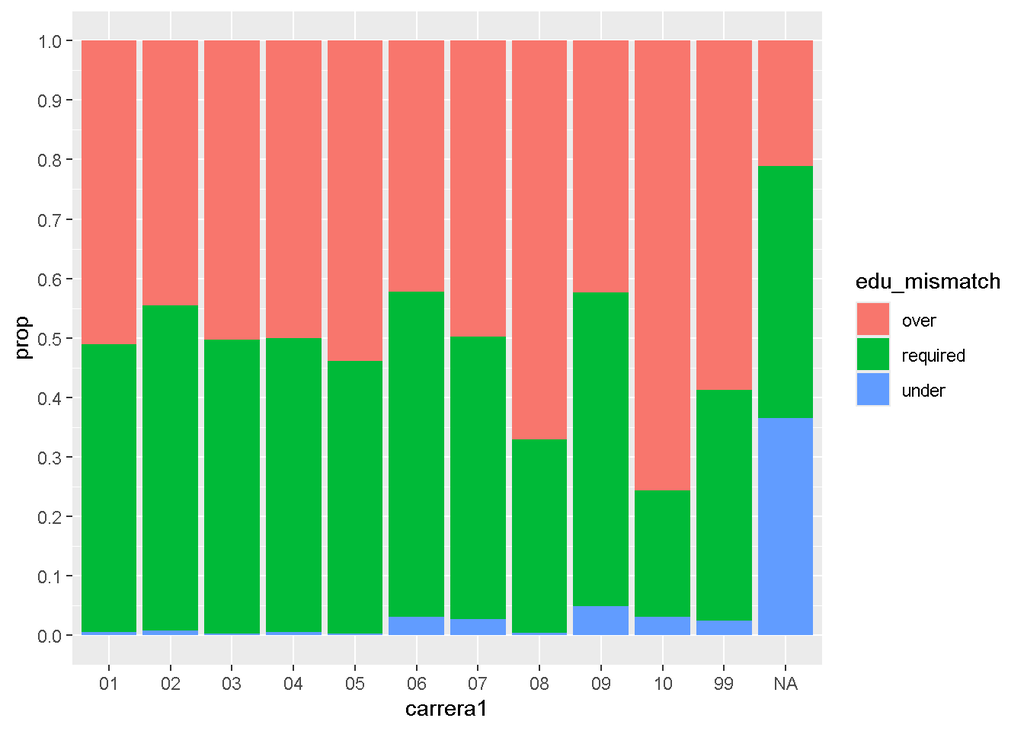

```r
jov_edu_mismatch %>%
  group_by(carrera1, edu_mismatch) %>%
  summarise(
    tot = sum(fac_tri.x)
  ) %>%
  mutate(prop = tot / sum(tot)) %>%
  ggplot(aes(carrera1, prop, fill = edu_mismatch)) +
  geom_col() +
  scale_y_continuous(
    breaks = seq(0, 1, by = 0.1)
  )
```

8 de 10 carreras universitarias tienen alrededor del 50% de jóvenes de 25 a 34 años sobre-educados, en específico la carrera de servicios (valor 10) tiene el 70% de sobre-educación.

### Con `anios_esc`

No obstante, también está el campo precodificado `anios_esc` que contiene los años de escolaridad.

```r
jovenes %>%
  count(anios_esc)
```

| anios_esc | n |
| --- | --- |
| 0 | 624 |
| 1 | 51 |
| 10 | 887 |
| 11 | 1777 |
| 12 | 14665 |
| 13 | 703 |
| 14 | 1194 |
| 15 | 1961 |
| 16 | 8130 |
| 17 | 8725 |

[output cut: 15 more lines]

¿Cambiarán sustancialmente los datos del desajuste educativo cuando se considere `anios_esc` y no `cs_p13_1`?

```r
jovenes_sr <- jovenes %>%
  group_by(ocupacion1, anios_esc) %>%
  summarise(
    tot = sum(fac_tri.x)
  ) %>%
  filter(tot == max(tot)) %>%
  mutate(s_r = anios_esc) %>%
  select(-(anios_esc:tot))
# definimos nueva tabla
jovenes2 <- left_join(jovenes, jovenes_sr, by = "ocupacion1")

jovenes_sr
```

| ocupacion1 | s_r |
| --- | --- |
| 1 | 16 |
| 2 | 16 |
| 3 | 12 |
| 4 | 12 |
| 5 | 12 |
| 6 | 9 |
| 7 | 9 |
| 8 | 12 |
| 9 | 9 |
| NA | 9 |

#### Incidencia

Incidencia de la sobre-educación

```r
jov_edu_mismatch <- jovenes2 %>%
  mutate(
    anios_esc = as.integer(anios_esc),
    s_r = as.integer(s_r),
    edu_mismatch = case_when(
      anios_esc > s_r ~ "over",
      anios_esc < s_r ~ "under",
      TRUE ~ "required"
    ),
    s_o = if_else(anios_esc > s_r, anios_esc - s_r, 0),
    s_u = if_else(s_r > anios_esc, s_r - anios_esc, 0),
  )

jov_edu_mismatch %>%
  count(edu_mismatch) %>%
  mutate(prop = n / sum(n))
```

| edu_mismatch | n | prop |
| --- | --- | --- |
| over | 25669 | 0.4330640 |
| required | 18927 | 0.3193191 |
| under | 14677 | 0.2476170 |

Con el campo precodificado `anios_esc` se observa una mayor proporción de jóvenes de 25 a 34 años sobre-educados (43%) con respecto a la variable `cs_p13_1` (32%).

#### Por grupos ocupacionales

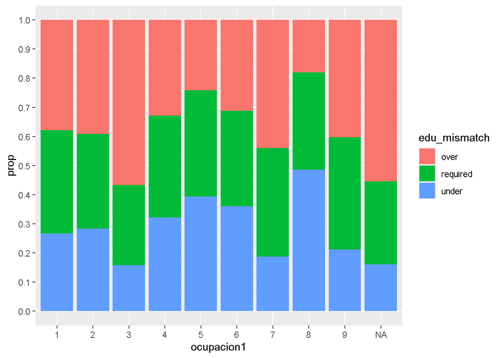

```r
jov_edu_mismatch %>%
  group_by(ocupacion1, edu_mismatch) %>%
  summarise(
    tot = sum(fac_tri.x)
  ) %>%
  mutate(prop = tot / sum(tot)) %>%
  ggplot(aes(ocupacion1, prop, fill = edu_mismatch)) +
  geom_col() +
  scale_y_continuous(
    breaks = seq(0, 1, by = 0.1)
  )
```

Por grupos ocupacionales también se observa una mayor proporción de sobre-educados, incluso en el caso de “Funcionarios, directores y jefes” (valor 1) que se encuentra alrededor del 40% con respecto al 10% con la variable `cs_p13_1`. Entonces, ¿qué variable utilizar?

## Mediana

Considero que utilizar la mediana facilita el código a realizar debido a que tiene su función en `R`.

### Con `cs_p13_1`

```r
jovenes %>%
  mutate(cs_p13_1 = as.integer(cs_p13_1)) %>%
  group_by(ocupacion1) %>%
  summarise(
    s_r = median(cs_p13_1)
  )
```

| ocupacion1 | s_r |
| --- | --- |
| 1 | 7 |
| 2 | 7 |
| 3 | 7 |
| 4 | 4 |
| 5 | 4 |
| 6 | 3 |
| 7 | 3 |
| 8 | 4 |
| 9 | 3 |
| NA | 4 |

#### Incidencia

```r
# anios requeridos
jovenes_sr <- jovenes %>%
  mutate(cs_p13_1 = as.integer(cs_p13_1)) %>%
  group_by(ocupacion1) %>%
  summarise(
    s_r = median(cs_p13_1)
  )

jovenes2 <- left_join(jovenes, jovenes_sr, by = "ocupacion1")

# variable de sobre educación
jov_edu_mismatch <- jovenes2 %>%
  mutate(
    cs_p13_1 = as.integer(cs_p13_1),
    edu_mismatch = case_when(
      cs_p13_1 > s_r ~ "over",
      cs_p13_1 < s_r ~ "under",
      TRUE ~ "required"
    ),
    s_o = if_else(cs_p13_1 > s_r, cs_p13_1 - s_r, 0),
    s_u = if_else(s_r > cs_p13_1, s_r - cs_p13_1, 0),
  )

# incidencia
jov_edu_mismatch %>%
  count(edu_mismatch) %>%
  mutate(prop = n / sum(n))
```

| edu_mismatch | n | prop |
| --- | --- | --- |
| over | 14805 | 0.2497765 |
| required | 26399 | 0.4453799 |
| under | 18069 | 0.3048437 |

En el caso de la moda, el porcentaje de sobre-educados jóvenes de 25 a 34 años es de 32% mientras que aquí del 25%.

### Con `anios_esc`

```r
jovenes %>%
  mutate(anios_esc = as.integer(anios_esc)) %>%
  group_by(ocupacion1) %>%
  summarise(
    mediana = median(anios_esc)
  )
```

| ocupacion1 | mediana |
| --- | --- |
| 1 | 16 |
| 2 | 16 |
| 3 | 15 |
| 4 | 12 |
| 5 | 12 |
| 6 | 9 |
| 7 | 9 |
| 8 | 12 |
| 9 | 9 |
| NA | 12 |

#### Incidencia

```r
# años requeridos
jovenes_sr <- jovenes %>%
  mutate(anios_esc = as.integer(anios_esc)) %>%
  group_by(ocupacion1) %>%
  summarise(
    s_r = median(anios_esc)
  )

jovenes2 <- left_join(jovenes, jovenes_sr, by = "ocupacion1")

# variable
jov_edu_mismatch <- jovenes2 %>%
  mutate(
    anios_esc = as.integer(anios_esc),
    edu_mismatch = case_when(
      anios_esc > s_r ~ "over",
      anios_esc < s_r ~ "under",
      TRUE ~ "required"
    ),
    s_o = if_else(anios_esc > s_r, anios_esc - s_r, 0),
    s_u = if_else(s_r > anios_esc, s_r - anios_esc, 0),
  )

# incidencia
jov_edu_mismatch %>%
  count(edu_mismatch) %>%
  mutate(prop = n / sum(n))
```

| edu_mismatch | n | prop |
| --- | --- | --- |
| over | 20776 | 0.3505137 |
| required | 17471 | 0.2947548 |
| under | 21026 | 0.3547315 |

Con `anios_esc` también disminuye la proporción de sobre-educados, aquí es del 35% mientras que con la moda es del 43%.

## Media +/- desv est

Por último, intentaremos determinar la incidencia con el método de Verdugo and Verdugo (1989).

### Años requeridos

```r
jovenes %>%
  mutate(anios_esc = as.double(anios_esc)) %>%
  group_by(ocupacion1) %>%
  summarise(
    media = mean(anios_esc),
    desv_std = sd(anios_esc),
    s_r_pos = media + desv_std,
    s_r_neg = media - desv_std
  ) %>%
  select(ocupacion1, s_r_neg, media, s_r_pos)
```

| ocupacion1 | s_r_neg | media | s_r_pos |
| --- | --- | --- | --- |
| 1 | 10.804558 | 15.301935 | 19.79931 |
| 2 | 10.181044 | 15.613548 | 21.04605 |
| 3 | 10.177947 | 14.060592 | 17.94324 |
| 4 | 7.277434 | 12.530102 | 17.78277 |
| 5 | 7.074852 | 11.920984 | 16.76712 |
| 6 | 3.597436 | 9.329327 | 15.06122 |
| 7 | 5.416918 | 10.488155 | 15.55939 |
| 8 | 6.478647 | 11.330352 | 16.18206 |
| 9 | 4.410678 | 10.188260 | 15.96584 |
| NA | 6.092211 | 11.421836 | 16.75146 |

Creo que para determinar la incidencia no es necesaria la variable `media` ya que: “Verdugo y Verdugo (1989) proponen considerar sobrecualificados a los trabajadores cuyos años de educación formal superan en una desviación típica a los años medios de su ocupación, e infracualificados a aquellos que se sitúan por debajo de una desviación típica de la media.” (Aguilar Ramos y García Crespo, 2008, p. 397). Es decir, con que esté por encima o por debajo de una desviación estándar se considerará sobre-educado o infra-educado, respectivamente.

```r
# años requeridos
jovenes_sr_vv <- jovenes %>%
  mutate(anios_esc = as.double(anios_esc)) %>%
  group_by(ocupacion1) %>%
  summarise(
    media = mean(anios_esc),
    desv_std = sd(anios_esc),
    s_r_pos = media + desv_std,
    s_r_neg = media - desv_std
  ) %>%
  select(ocupacion1, s_r_neg, s_r_pos)

jovenes2_vv <- left_join(jovenes, jovenes_sr_vv, by = "ocupacion1")

# variable
jov_edu_mis_vv <- jovenes2_vv %>%
  mutate(
    anios_esc = as.integer(anios_esc),
    edu_mismatch = case_when(
      anios_esc > s_r_pos ~ "over",
      anios_esc < s_r_neg ~ "under",
      TRUE ~ "required"
    )
  )

# incidencia
jov_edu_mis_vv %>%
  group_by(edu_mismatch) %>%
  summarise(tot = sum(fac_tri.x)) %>%
  mutate(prop = tot / sum(tot))
```

| edu_mismatch | tot | prop |
| --- | --- | --- |
| over | 1052022 | 0.05657321 |
| required | 15974114 | 0.85901901 |
| under | 1569627 | 0.08440778 |

Se evidencia una reducción sustancial del porcentaje de sobre-educados con el método de Verdugo y Verdugo (6%) con respecto a los demás métodos (moda 32% y mediana 25%)

# Distribución de años de estudio

La duda es ¿cómo es la distribución de los años de educación de los individuos? Primero se conocen los valores de la variable `cs_p13_1`.

```r
unique(jovenes$cs_p13_1)
```

```
##  [1] "7"  "2"  "3"  "9"  "4"  "8"  "0"  "6"  "99" "1"
```

## De `cs_p13_1`

Después se grafica la distribución

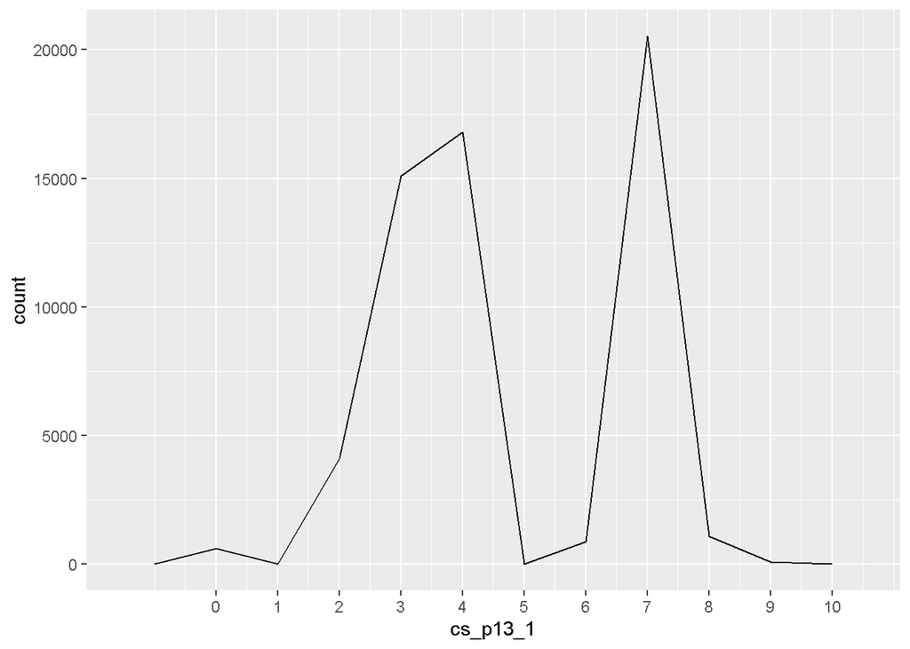

```r
jovenes %>%
  filter(cs_p13_1 != "99") %>%
  mutate(cs_p13_1 = as.integer(cs_p13_1)) %>%
  ggplot(aes(cs_p13_1)) +
  geom_freqpoly(binwidth = 1) +
  scale_x_continuous(
    breaks = seq(0, 10, by = 1)
  )
```

## De `anios_esc`

```r
unique(jovenes$anios_esc)
```

```
##  [1] "16" "6"  "9"  "19" "17" "12" "18" "15" "0"  "14" "13" "11" "10" "3"  "5"
## [16] "8"  "4"  "7"  "2"  "20" "1"  "99" "21" "23" "22"
```

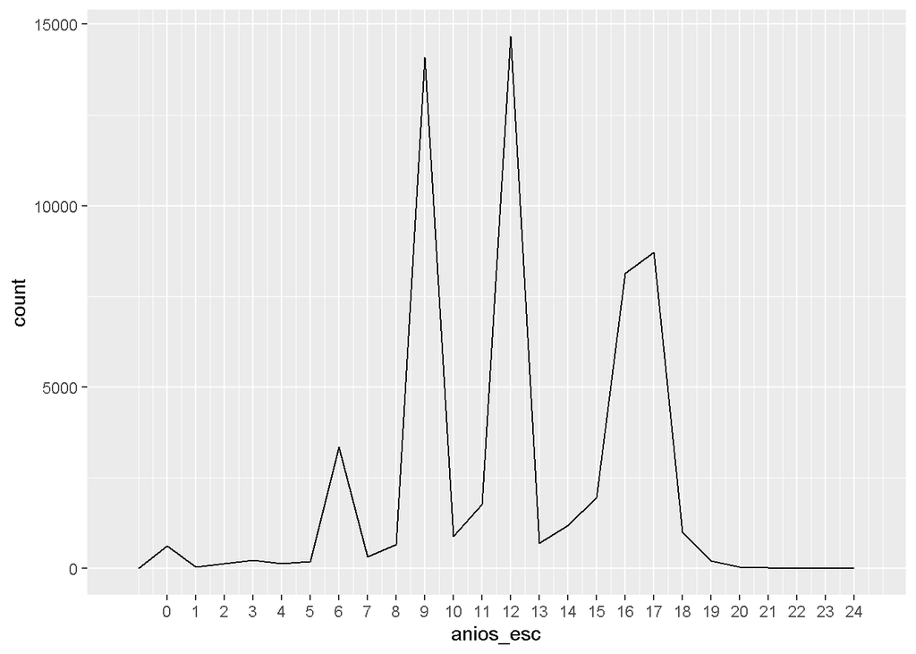

```r
jovenes %>%
  filter(anios_esc != "99") %>%
  mutate(anios_esc = as.integer(anios_esc)) %>%
  ggplot(aes(anios_esc)) +
  geom_freqpoly(binwidth = 1) +
  scale_x_continuous(
    breaks = seq(0, 24, by = 1)
  )
```

## Por grupos ocupacionales

¿Cuál es el coeficiente de asimetría de la distribución de años de escolaridad que poseen los jóvenes?

Por grupos ocupacionales

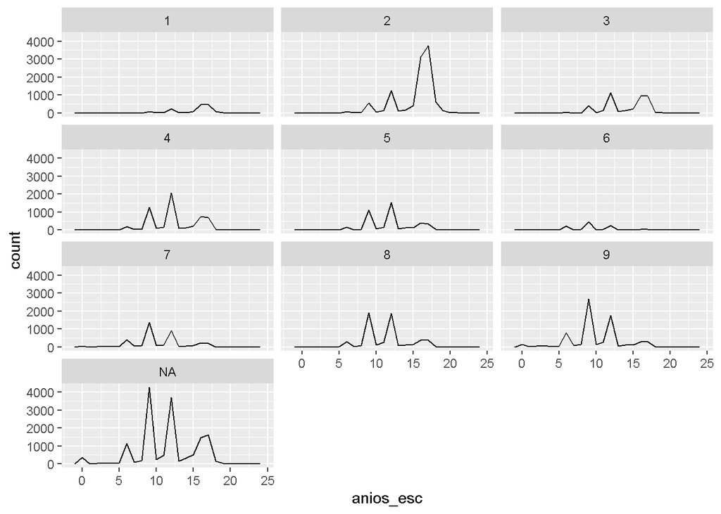

```r
jovenes %>%
  filter(anios_esc != "99") %>%
  mutate(anios_esc = as.integer(anios_esc)) %>%
  ggplot(aes(anios_esc)) +
  geom_freqpoly(binwidth = 1) +
  facet_wrap(~ ocupacion1, ncol = 3)
```

En ningún caso, la distribución tiene una sola campana. ¿Lo conveniente sería determinar los años de educación requerida mediante el grupo ocupacional principal? Véase INEGI (2020) p. 31 Trabajemos directamente con la tabla `completo`.

## De la población de 15 años y más

Con `anios_esc`

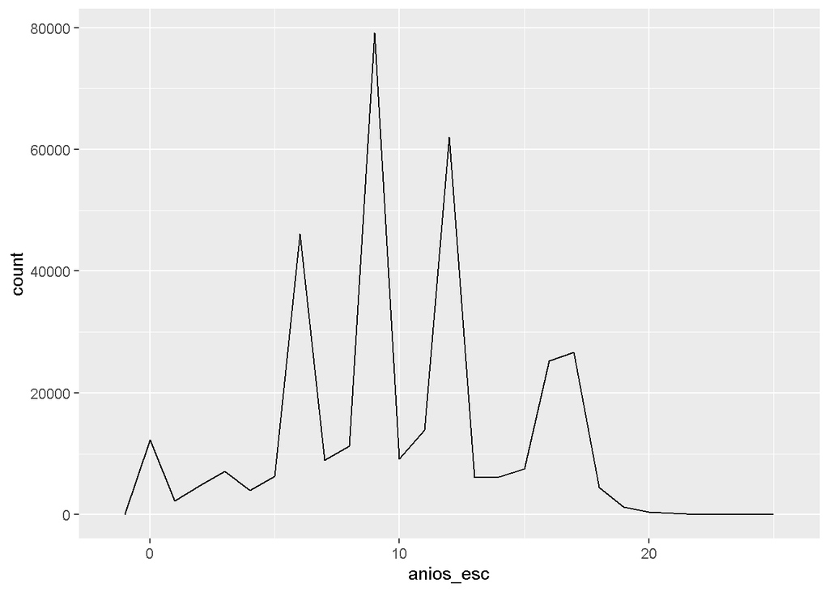

```r
completo %>%
  mutate(anios_esc = as.integer(anios_esc)) %>%
  filter(anios_esc != 99) %>%
  ggplot(aes(anios_esc)) +
  geom_freqpoly(binwidth = 1 )
```

## De la PEA

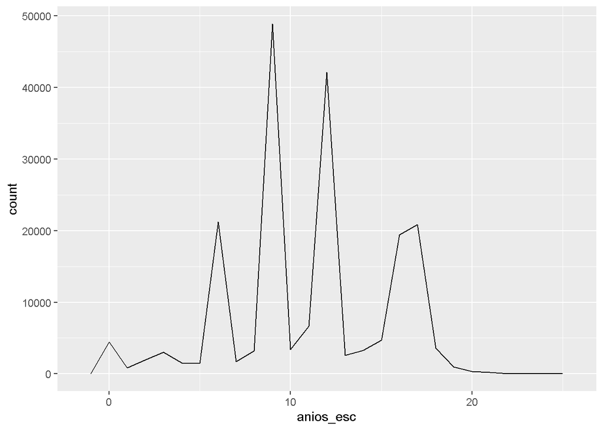

```r
completo %>%
  mutate(anios_esc = as.integer(anios_esc)) %>%
  filter(anios_esc != 99 & clase1 == 1) %>%
  ggplot(aes(anios_esc)) +
  geom_freqpoly(binwidth = 1 )
```

# Estadística descriptiva

Años de escolaridad con `anios_esc`

```r
completo %>%
  filter(anios_esc != 99 & clase1 == 1) %>%
  mutate(anios_esc = as.integer(anios_esc)) %>%
  summarise(
    media = mean(anios_esc),
    mediana = median(anios_esc),
    desv_std = sd(anios_esc)
  )
```

| media | mediana | desv_std |
| --- | --- | --- |
| 10.97108 | 11 | 4.26972 |

Moda

```r
completo %>%
  filter(anios_esc != 99 & clase1 == 1) %>%
  mutate(anios_esc = as.integer(anios_esc)) %>%
  group_by(anios_esc) %>%
  summarise(tot = sum(fac_tri.x)) %>%
  filter(tot == max(tot))
```

| anios_esc | tot |
| --- | --- |
| 9 | 15142815 |

## Por grupos ocupacionales

```r
anios_edu_m1 <- completo %>%
  filter(anios_esc != 99 & clase1 == 1) %>%
  mutate(anios_esc = as.integer(anios_esc)) %>%
  group_by(ocupacion1) %>%
  summarise(
    media = mean(anios_esc),
    mediana = median(anios_esc),
    desv_std = sd(anios_esc)
  )

anios_edu_m2 <- completo %>%
  filter(anios_esc != 99 & clase1 == 1) %>%
  mutate(anios_esc = as.integer(anios_esc)) %>%
  group_by(ocupacion1, anios_esc) %>%
  summarise(tot = sum(fac_tri.x)) %>%
  filter(tot == max(tot))
(anios_edu_mtc <- left_join(anios_edu_m1, anios_edu_m2, by = "ocupacion1") %>%
  select(-tot))
```

| ocupacion1 | media | mediana | desv_std | anios_esc |
| --- | --- | --- | --- | --- |
| 1 | 14.916385 | 16 | 3.079188 | 16 |
| 2 | 14.820511 | 16 | 3.262229 | 16 |
| 3 | 13.311296 | 12 | 3.070516 | 12 |
| 4 | 10.958900 | 12 | 3.701189 | 12 |
| 5 | 10.398857 | 11 | 3.449739 | 9 |
| 6 | 6.728178 | 6 | 4.105514 | 6 |
| 7 | 8.799210 | 9 | 3.745017 | 9 |
| 8 | 10.345881 | 9 | 3.056612 | 9 |
| 9 | 8.608628 | 9 | 3.583096 | 9 |
| NA | 11.939909 | 12 | 3.871224 | 12 |

# Coeficiente de asimetría

```r
# system.file(package = "moments")
# system.file(package = "EnvStats")
#
# install.packages("moments", dependencies = TRUE)
# install.packages("EnvStats", dependencies = TRUE)

# library(moments)
# library(EnvStats)

# variable de años de escolaridad
anios_edu <- completo %>%
  filter(anios_esc != 99) %>%
  transmute(anios_esc = as.integer(anios_esc))

# se corrobora asignación
# anios_edu %>%
# ggplot(aes(anios_esc)) +
#   geom_freqpoly(binwidth = 1)

moments::skewness(anios_edu$anios_esc)
```

```
## [1] -0.1331026
```

```r
EnvStats::skewness(anios_edu$anios_esc)
```

```
## [1] -0.1331032
```

Existe un pequeño sesgo a la izquierda en la distribución de años de escolaridad con `anios_esc`. ¿Puedo hacerlo por grupos ocupacionales? En primer lugar, se valida si se puede trabajar con los verbos de `tidyverse`.

```r
anios_edu %>%
  summarise(
    sesgo = EnvStats::skewness(anios_esc)
  )
```

| sesgo |
| --- |
| -0.1331032 |

Si se puede trabajar

## Por grupos ocupacionales

```r
completo %>%
  filter(anios_esc != 99) %>%
  mutate(anios_esc = as.integer(anios_esc)) %>%
  group_by(ocupacion1) %>%
  summarise(sesgo = EnvStats::skewness(anios_esc))
```

| ocupacion1 | sesgo |
| --- | --- |
| 1 | -1.11436982 |
| 2 | -1.23329082 |
| 3 | -0.39148126 |
| 4 | -0.32548434 |
| 5 | -0.32084763 |
| 6 | 0.18254159 |
| 7 | -0.07292241 |
| 8 | 0.04599389 |
| 9 | -0.26843500 |
| NA | -0.02594109 |

Se observa mayor sesgo negativo, principalmente en los grupos 1 y 2.

Veamos de forma gráfica

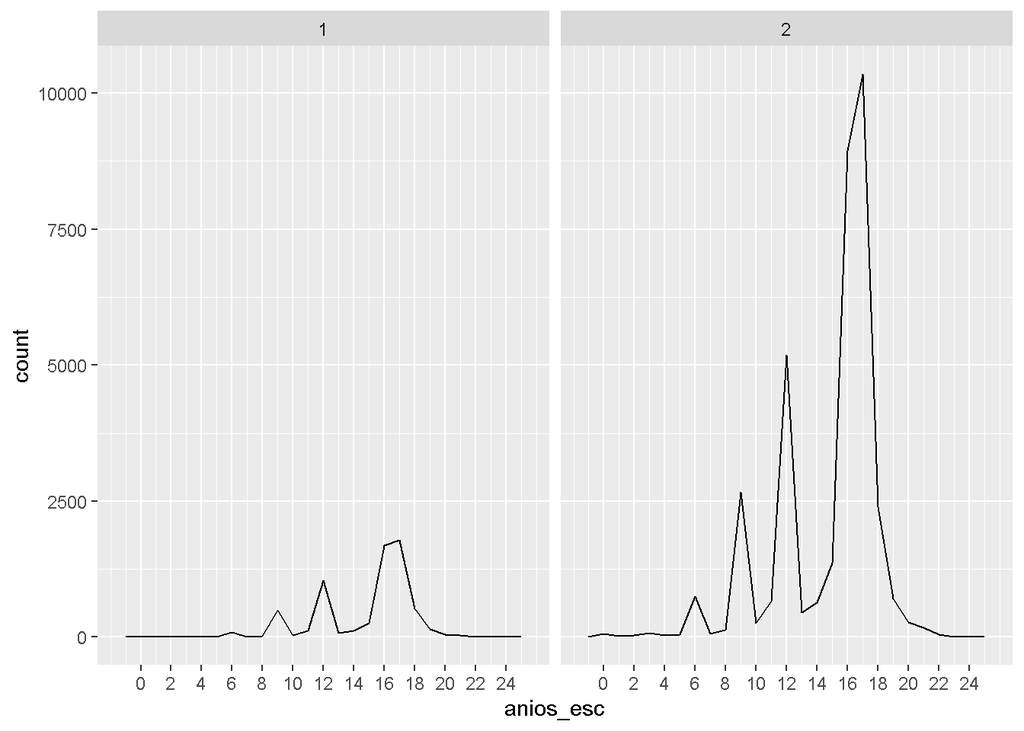

```r
completo %>%
  filter(anios_esc != 99 & (ocupacion1 == 1 | ocupacion1 == 2)) %>%
  mutate(anios_esc = as.integer(anios_esc)) %>%
  ggplot(aes(anios_esc)) +
  geom_freqpoly(binwidth = 1) +
  facet_grid(~ ocupacion1) +
  scale_x_continuous(breaks = seq(0, 24, by = 2))
```

Comparando con los años requeridos por media, moda y mediana, no se observan diferencias al utilizar la mediana y la moda, excepto en el grupo 5 “Trabajadores en servicios personales y de vigilancia” lo que sobre estimará el porcentaje de individuos sobre-educados. Por otra parte, se observa una elevada proporción de individuos con años de escolaridad menor a la requerida (ya sea con la media, moda o mediana) en el grupo 1 y 2; puede deberse a que los subgrupos ocupacionales son diversos, por ejemplo, en el grupo 2 existen la ocupación 21 “Profesionistas en ciencias económico-administrativas, ciencias sociales, humanistas y en artes” y a su vez la ocupación 25 “Auxiliares y técnicos en ciencias económico-administrativas, ciencias sociales, humanistas y en artes”, desde nuestro punto de vista son ocupaciones que pueden requerir años de educación requeridas diferentes por lo que se obtendrá los años de escolaridad requeridos en el grupo ocupacional principal con el método de la moda. Hagámoslo con la tabla `jovenes` para fines comparativos.

# Años requeridos con grupo principal

Grupo ocupacional: división

```r
jovenes %>%
  group_by(ocupacion1, anios_esc) %>%
  summarise(
    tot = sum(fac_tri.x)
  ) %>%
  filter(tot == max(tot))
```

| ocupacion1 | anios_esc | tot |
| --- | --- | --- |
| 1 | 16 | 186941 |
| 2 | 16 | 1020217 |
| 3 | 12 | 350504 |
| 4 | 12 | 659987 |
| 5 | 12 | 440633 |
| 6 | 9 | 159539 |
| 7 | 9 | 436098 |
| 8 | 12 | 562705 |
| 9 | 9 | 890089 |
| NA | 9 | 1405277 |

Grupo ocupacional: principal

```r
# años de escolaridad requerida
edu_req_ocu2 <- jovenes %>%
  group_by(ocupacion2, anios_esc) %>%
  summarise(
    tot = sum(fac_tri.x)
  ) %>%
  filter(tot == max(tot)) %>%
  select(-tot) %>%
  rename("edu_req" = "anios_esc")
# variable de desajuste educativo
edu_mis_ocu2 <-  left_join(jovenes, edu_req_ocu2, by = "ocupacion2") %>%
  filter(anios_esc != 99) %>%
  mutate(
    anios_esc = as.integer(anios_esc),
    edu_req = as.integer(edu_req),
    edu_mis = case_when(
      anios_esc > edu_req ~ "over",
      anios_esc < edu_req ~ "under",
      TRUE ~ "required"
    )
  )
```

## Incidencia

```r
# general
edu_mis_ocu2 %>%
  group_by(edu_mis) %>%
  summarise(tot = sum(fac_tri.x)) %>%
  mutate(prop = tot / sum(tot))
```

| edu_mis | tot | prop |
| --- | --- | --- |
| over | 7506936 | 0.4046161 |
| required | 6515386 | 0.3511726 |
| under | 4530907 | 0.2442112 |

Duda, ¿y si lo construyo con el grupo ocupacional de menor desagregación?

# Años requeridos con grupo unitario

LA variable que contiene el grupo ocupacional de menor agregación (unitario) en la tabla `jovenes` es la que viene por defecto en la fuente de datos: `p3`

```r
jovenes %>%
  select(p3)
```

| p3 |
| --- |
| 4201 |
| 3132 |
| NA |
| 9611 |
| NA |
| 2135 |
| NA |
| NA |
| 2332 |
| 3211 |

[output cut: 9990 more lines]

Primero, ¿cuáles son los primeros momentos de años de escolaridad en cada grupo ocupacional?

```r
jovenes %>%
  filter(anios_esc != 99) %>%
  mutate(anios_esc = as.integer(anios_esc)) %>%
  group_by(p3) %>%
  summarise(
    n = n(),
    media = mean(anios_esc),
    mediana = median(anios_esc),
    desv_std = sd(anios_esc),
    sesgo = EnvStats::skewness(anios_esc)
  )
```

| p3 | n | media | mediana | desv_std | sesgo |
| --- | --- | --- | --- | --- | --- |
| 1112 | 2 | 17.500000 | 17.5 | 0.7071068 | NA |
| 1113 | 18 | 14.166667 | 16.0 | 3.5021002 | -0.784729526 |
| 1121 | 6 | 15.000000 | 16.0 | 2.3664319 | -0.814970174 |
| 1122 | 29 | 15.689655 | 16.0 | 2.2217022 | -3.272222843 |
| 1131 | 1 | 16.000000 | 16.0 | NA | NA |
| 1132 | 1 | 11.000000 | 11.0 | NA | NA |
| 1134 | 1 | 17.000000 | 17.0 | NA | NA |
| 1135 | 3 | 15.000000 | 16.0 | 2.6457513 | -1.457862967 |
| 1211 | 78 | 15.782051 | 16.0 | 1.6798843 | -1.839104059 |
| 1212 | 70 | 15.528571 | 16.0 | 2.1177061 | -1.709157070 |

[output cut: 456 more lines]

Moda

```r
jovenes %>%
  filter(anios_esc != 99) %>%
  mutate(anios_esc = as.integer(anios_esc)) %>%
  group_by(p3, anios_esc) %>%
  summarise(tot = sum(fac_tri.x)) %>%
  filter(tot == max(tot))
```

[output not shown]

| p3 | anios_esc | tot |
| --- | --- | --- |
| 1112 | 17 | 119 |
| 1113 | 9 | 1906 |
| 1121 | 12 | 570 |
| 1122 | 16 | 8089 |
| 1131 | 16 | 119 |
| 1132 | 11 | 567 |
| 1134 | 17 | 89 |
| 1135 | 12 | 887 |
| 1211 | 16 | 20906 |
| 1212 | 16 | 20372 |

[output cut: 457 more lines]

Se observan diferencias significativas cuando se compara la mediana y la moda, por ejemplo el grupo `1113` la mediana es `16` mientras que la moda es `9`. Como señalé anteriormente, parece que la moda sobre estimará el porcentaje de sobre-educados. En dichos casos, lo recomendable es tener un cuadro comparativo de los tipos de métodos. Considerar.

## Moda

Entonces, determino los años de educación requerido para cada ocupación con el método de la moda.

```r
# años de escolaridad requerida
edu_req_p3 <- jovenes %>%
  group_by(p3, anios_esc) %>%
  summarise(
    tot = sum(fac_tri.x)
  ) %>%
  filter(tot == max(tot)) %>%
  select(-tot) %>%
  rename("edu_req" = "anios_esc")
```

[output not shown]

```r
# variable de desajuste educativo
edu_mis_p3 <-  left_join(jovenes, edu_req_p3, by = "p3") %>%
filter(anios_esc != 99) %>%
mutate(
  anios_esc = as.integer(anios_esc),
  edu_req = as.integer(edu_req),
  edu_mis = case_when(
    anios_esc > edu_req ~ "over",
    anios_esc < edu_req ~ "under",
    TRUE ~ "required"
  )
)
# incidencia
edu_mis_p3 %>%
  group_by(edu_mis) %>%
  summarise(tot = sum(fac_tri.x)) %>%
  mutate(prop = tot / sum(tot))
```

| edu_mis | tot | prop |
| --- | --- | --- |
| over | 7018390 | 0.3781749 |
| required | 6915119 | 0.3726103 |
| under | 4625072 | 0.2492147 |

## Mediana

Con la mediana

```r
# años de escolaridad requerida
edu_req_p3 <- jovenes %>%
  filter(anios_esc != 99) %>%
  mutate(anios_esc = as.integer(anios_esc)) %>%
  group_by(p3) %>%
  summarise(
    edu_req = median(anios_esc)
  )

# variable de desajuste educativo
edu_mis_p3 <-  left_join(jovenes, edu_req_p3, by = "p3") %>%
mutate(
  anios_esc = as.integer(anios_esc),
  edu_mis = case_when(
    anios_esc > edu_req ~ "over",
    anios_esc < edu_req ~ "under",
    TRUE ~ "required"
  )
)

# incidencia
edu_mis_p3 %>%
  group_by(edu_mis) %>%
  summarise(tot = sum(fac_tri.x)) %>%
  mutate(prop = tot / sum(tot))
```

| edu_mis | tot | prop |
| --- | --- | --- |
| over | 5372930 | 0.2889330 |
| required | 5955524 | 0.3202624 |
| under | 7267309 | 0.3908046 |

Arroja un error al momento de unir, comprobemos nuestro resultado con la mediana

```r
# años de escolaridad requerida
edu_req_p3 <- jovenes %>%
  filter(anios_esc != 99) %>%
  mutate(anios_esc = as.integer(anios_esc)) %>%
  group_by(p3) %>%
  summarise(
    edu_req = median(anios_esc)
  )

edu_req_p3 %>% filter(p3 == 4201)
```

| p3 | edu_req |
| --- | --- |
| 4201 | 12 |

Unión

```r
# variable de desajuste educativo
left_join(jovenes, edu_req_p3, by = "p3") %>%
  select(p3, anios_esc, edu_req) %>%
  mutate(
    anios_esc = as.double(anios_esc),
    edu_mis = case_when(
      anios_esc > edu_req ~ "over",
      anios_esc < edu_req ~ "under",
      TRUE ~ "required"
    )
  )
```

| p3 | anios_esc | edu_req | edu_mis |
| --- | --- | --- | --- |
| 4201 | 16 | 12.0 | over |
| 3132 | 6 | 12.0 | under |
| NA | 9 | 12.0 | under |
| 9611 | 9 | 9.0 | required |
| NA | 19 | 12.0 | over |
| 2135 | 17 | 17.0 | required |
| NA | 12 | 12.0 | required |
| NA | 9 | 12.0 | under |
| 2332 | 18 | 16.0 | over |
| 3211 | 18 | 16.0 | over |

[output cut: 9990 more lines]

Por fortuna, nuestro resultado es correcto. No obstante, quisiera señalar que con la mediana, el grupo `4201` “Encargados y supervisores de ventas de productos y de servicios financieros” tiene una educación requerida de 12 años equivalente a preparatoria cuando, en teoría, podría suponer una educación superior.

# Utilizar los tres métodos

Ahora bien, ¿podré construir un cuadro comparativo con los tres métodos?

```r
# métodos: verdugo y verdugo, y mediana
edu_req_g1 <- jovenes %>%
  mutate(anios_esc = as.double(anios_esc)) %>%
  group_by(ocupacion1) %>%
  summarise(
    vv_neg = mean(anios_esc) - sd(anios_esc),
    vv_pos = mean(anios_esc) + sd(anios_esc),
    mediana = median(anios_esc)
  )

# método: moda
edu_req_g2 <- jovenes %>%
  group_by(ocupacion1, anios_esc) %>%
  summarise(
    tot = sum(fac_tri.x)
  ) %>%
    filter(tot == max(tot)) %>%
    rename("moda" = "anios_esc") %>%
    select(-tot)
# variable de desajuste
edu_mis_g <- left_join(jovenes, edu_req_g1, by = "ocupacion1") %>%
  left_join(edu_req_g2, by = "ocupacion1") %>%
  mutate(
    anios_esc = as.double(anios_esc),
    moda = as.double(moda),
    # verdugo y verdugo
    edu_mis_vv = case_when(
      anios_esc > vv_pos ~ "over",
      anios_esc < vv_neg ~ "under",
      TRUE ~ "required"
    ),
    # mediana
    edu_mis_med = case_when(
      anios_esc > mediana ~ "over",
      anios_esc < mediana ~ "under",
      TRUE ~ "required"
    ),
    # moda
    edu_mis_mod = case_when(
      anios_esc > moda ~ "over",
      anios_esc < moda ~ "under",
      TRUE ~ "required"
    )
  )
```

Verdugo y Verdugo

```r
edu_mis_g %>%
  group_by(edu_mis_vv) %>%
  summarise(tot = sum(fac_tri.x)) %>%
  mutate(prop = tot / sum(tot))
```

| edu_mis_vv | tot | prop |
| --- | --- | --- |
| over | 1052022 | 0.05657321 |
| required | 15974114 | 0.85901901 |
| under | 1569627 | 0.08440778 |

Mediana

```r
edu_mis_g %>%
  group_by(edu_mis_med) %>%
  summarise(tot = sum(fac_tri.x)) %>%
  mutate(prop = tot / sum(tot))
```

| edu_mis_med | tot | prop |
| --- | --- | --- |
| over | 6147940 | 0.3306097 |
| required | 5602590 | 0.3012831 |
| under | 6845233 | 0.3681071 |

Moda

```r
edu_mis_g %>%
  group_by(edu_mis_mod) %>%
  summarise(tot = sum(fac_tri.x)) %>%
  mutate(prop = tot / sum(tot))
```

| edu_mis_mod | tot | prop |
| --- | --- | --- |
| over | 7683158 | 0.4131671 |
| required | 6111990 | 0.3286765 |
| under | 4800615 | 0.2581564 |

Listo!

Se puede crear tablas y unirlas para tenerlas en una sola

```r
verdugo <- edu_mis_g %>%
  group_by(edu_mis_vv) %>%
  summarise(tot = sum(fac_tri.x)) %>%
  mutate(prop = tot / sum(tot)) %>%
  rename(
    "Tipo" = "edu_mis_vv",
    "Media" = "prop"
  ) %>%
  select(-tot)

mediana <- edu_mis_g %>%
  group_by(edu_mis_med) %>%
  summarise(tot = sum(fac_tri.x)) %>%
  mutate(prop = tot / sum(tot)) %>%
  rename(
    "Tipo" = "edu_mis_med",
    "Mediana" = "prop"
  ) %>%
  select(-tot)

moda <- edu_mis_g %>%
  group_by(edu_mis_mod) %>%
  summarise(tot = sum(fac_tri.x)) %>%
  mutate(prop = tot / sum(tot)) %>%
  rename(
    "Tipo" = "edu_mis_mod",
    "Moda" = "prop"
  ) %>%
  select(-tot)

desajuste <- left_join(verdugo, mediana, by = "Tipo") %>%
  left_join(moda, by = "Tipo") %>%
  mutate(
    Tipo = factor(Tipo),
    Tipo = fct_recode(
      Tipo,
      "Sobre-educación" = "over",
      "Requerida" = "required",
      "Infra-educación" = "under"
    )
  )

desajuste
```

| Tipo | Media | Mediana | Moda |
| --- | --- | --- | --- |
| Sobre-educación | 0.05657321 | 0.3306097 | 0.4131671 |
| Requerida | 0.85901901 | 0.3012831 | 0.3286765 |
| Infra-educación | 0.08440778 | 0.3681071 | 0.2581564 |

Se observa que sólo el 6% de jóvenes de 25 a 34 años está sobre-educado con el método de la media, el 33% con la mediana y hasta un 41% con la moda. ¿Cómo hacerlo de forma gráfica?

# Resumen

En línea con las sugerencias de mi director de tesis, realizaré lo siguiente:

- Determinar la incidencia de la sobre-educación solamente con el método de la moda, mostraré la incidencia de forma desagregada desde el lado de la oferta (trabajadores), y no de la demanda (puestos de trabajo), ya que me interesa conocer el número (absoluto y relativo) de sobre-educados por carrera universitaria. En ese sentido, trabajaré con las variables `carrera3` y no con `ocupacion2`.
- Determinar los años de escolaridad requeridos con el grupo de mayor agregación (división), por lo que eliminaré el valor `NA`.
- Utilizar la variable `anios_esc` para conocer los años de escolaridad individual, por lo que transformaré dicho valor a numérico (entero o racional) y eliminaré el valor `99` ya que representa `No sabe`

# Efecto salarial

Recordemos que los estudios empíricos llevados a cabo rechazan los postulados de la Teoría de Capital Humano (Becker (1983), Mincer (1974), Schultz (1961)) y el Modelo de Competencia de Puestos de trabajo (Thurow (1975)) con el modelo ORU (Over, Required, Under) propuesto por Duncan and Hoffman (1981), entonces al rechazar ambas teorías se acepta lo propuesto por la Teoría de Asignación Sattinger (1993), es decir, que existe tanto un efecto educación como un efecto ocupación en la formación del ingreso (Zamudio and Islas (1999)).

En ese sentido, el modelo ORU que considera ambos efectos es el siguiente (Zamudio and Islas (1999)):

$$y_i = \phi_1 + \phi_2 S_i^R + \phi_3 G_i S_i^o + \phi_4 H_i S_i^u +
\sum_{j = 1}^J L_{ij} + \gamma X_i + \epsilon_i$$

Con

$$S^o_i = S_i - S^R_i; S_i > S^R_i \\
S^u_i = S^R_i - S_i; S_i < S^R_i$$

Donde:

$y_i$: logaritmo natural del ingreso,  
$S_i^R$: años de educación requerida,  
$S_i^o$: años de sobre-educación,  
$S_i^u$: años de infra-educación,  
$G_i$: variable dicotómica que indica sobre-educación,  
$H_i$: variable dicotómica que indica infra-educación,  
$\sum_{j = 1}^J L_{ij}$: variables dicotómicas de las $J$ ocupaciones,  
$X_i$: variables exógenas como edad, experiencia laboral, género, región de residencia, horas trabajadas, etc.

Cabe señalar que los autores utilizan variables dicotómicas “para los casos en que las discrepancias en educación sean positivas o negativas” (Zamudio and Islas (1999) p. 7), no obstante, el modelo ORU planteado por Hartog (2000) no existe ninguna variable dicotómica similar:

$$\ln{W} = X \beta + \gamma_r S_r + \gamma_o S_o + \gamma_u S_u +
\epsilon$$

Donde:

$S_r$: años de educación requerida para el puesto,  
$S_o$: años de sobre-educación (educación adquirida menos la educación requerida, si es positivo, en caso contrario será cero),  
$S_u$: años de infra-educación,  
$X$: otras variables explicativas

Sin embargo, no son modelos iguales; el modelo de Zamudio e Islas considera el efecto educación y ocupación en la formación del ingreso mediante las variables dicotómicas asociadas a cada ocupación, mientras que el modelo ORU también contempla ambos efectos pero sólo en la variable $S_o$.

Por otra parte, como la población objetivo son los jóvenes profesionistas se espera que la proporción de infra-educados sea prácticamente cero por lo que el modelo puede quedar de la siguiente manera:

$$y_i = \phi_1 + \phi_2 S_i^R + \phi_3 G_i S_i^o + \sum_{j = 1}^J L_{ij} +
\gamma X_i + \epsilon_i$$

De igual manera, se construirán variables categóricas que nos permitan contar el número (absoluto y relativo) de individuos con desajuste educativo, tanto con sobre-educación como con infra-educación.

Por último, cabe señalar que Zamudio and Islas (1999) se basaron en el trabajo de Hartog (1985) para construir el modelo ORU ampliado. Sin embargo, este último no ha sido leído.

# Referencias

Becker, Gary Stanley. 1983. *El Capital Humano. Un análisis Teórico y Empírico Referido Fundamentalmente a La Educación*. Translated by Marta Casares and José Vergara. Madrid: Alianza Editorial.

Capsada-Munsech, Queralt. 2017. “Overeducation: Concept, Theories, and Empirical Evidence.” *Sociology Compass* 11 (10): e12518. https://doi.org/10.1111/soc4.12518.

Di Pietro, Giorgio, and Peter Urwin. 2006. “Education and Skills Mismatch in the Italian Graduate Labour Market.” *Applied Economics* 38 (1): 79–93. https://doi.org/10.1080/00036840500215303.

Dolton, Peter, and Mary A. Silles. 2001. *Over-Education in the Graduate Labour Market: Some Evidence from Alumni Data*. {{CEE Discussion Papers}} No. CEEDP0009. Centre for the Economics of Education, London School of Economics.

Duncan, Greg J., and Saul D. Hoffman. 1981. “The Incidence and Wage Effects of Overeducation.” *Economics of Education Review* 1 (1): 75–86. https://doi.org/10.1016/0272-7757(81)90028-5.

García-Montalvo, José., and José María. Peiró. 2009. *Análisis de la sobrecualificación y la flexibilidad laboral. Observatorio de Inserción Laboral de los Jóvenes 2008*. Valencia: Fundación Bancaja.

Groot, Wim, and Henriëtte Maassen van den Brink. 2000. “Overeducation in the Labor Market: A Meta-Analysis.” *Economics of Education Review* 19 (2): 149–58. https://doi.org/10.1016/S0272-7757(99)00057-6.

Hartog, Joop. 1985. “Earnings Functions. Testing for the Demand Side.” *Economics Letters* 19 (3): 281–85. https://doi.org/10.1016/0165-1765(85)90037-0.

Hartog, Joop. 2000. “Over-Education and Earnings: Where Are We, Where Should We Go?” *Economics of Education Review* 19 (2): 131–47. https://doi.org/10.1016/S0272-7757(99)00050-3.

ILO. 2021. “Sólo la mitad de los trabajadores de todo el mundo ocupan puestos de trabajo correspondientes a su nivel de formación.” In *ILOSTAT*.

ILO. 2024. *Global Employment Trends for Youth 2024: Decent Work, Brighter Futures*. GET for Youth, 20th anniversary edition. Geneva: ILO.

INEGI. 2020. *Sistema Nacional de Clasificación de Ocupaciones 2019. SINCO*.

Kiker, B. F., María C. Santos, and M. Mendes De Oliveira. 1997. “Overeducation and Undereducation: Evidence for Portugal.” *Economics of Education Review* 16 (2): 111–25. https://doi.org/10.1016/S0272-7757(96)00040-4.

McGuinness, Séamus. 2006. “Overeducation in the Labour Market.” *Journal of Economic Surveys* 20 (3): 387–418. https://doi.org/10.1111/j.0950-0804.2006.00284.x.

Mehta, Aashish, Jesus Felipe, Pilipinas Quising, and Sheila Camingue. 2011. “Overeducation in Developing Economies: How Can We Test for It, and What Does It Mean?” *Economics of Education Review* 30 (6): 1334–47. https://doi.org/10.1016/j.econedurev.2011.06.004.

Mincer, Jacob A. 1974. *Schooling, Experience, and Earnings*. Human Behavior and Social Institutions 2. New York: National Bureau of Economic Research (NBER).

OECD. 2019. *Educación superior en México: Resultados y relevancia para el mercado laboral*. París: OECD Publishing. https://doi.org/10.1787/a93ed2b7-es.

Quinn, Michael A., and Stephen Rubb. 2006. “Mexico’s Labor Market: The Importance of Education-Occupation Matching on Wages and Productivity in Developing Countries.” *Economics of Education Review* 25 (2): 147–56. https://doi.org/10.1016/j.econedurev.2005.01.003.

Rubb, S. 2003. “Overeducation in the Labor Market: A Comment and Re-Analysis of a Meta-Analysis.” *Economics of Education Review* 22 (6): 621–29. https://doi.org/10.1016/S0272-7757(02)00077-8.

Rumberger, Russell W. 1981. “The Rising Incidence of Overeducation in the U.S. Labor Market.” *Economics of Education Review* 1 (3): 293–314. https://doi.org/10.1016/0272-7757(81)90001-7.

Rumberger, Russell W. 1987. “The Impact of Surplus Schooling on Productivity and Earnings.” *The Journal of Human Resources* 22 (1): 24–50. https://doi.org/10.2307/145865.

Sattinger, Michael. 1993. “Assignment Models of the Distribution of Earnings.” *Journal of Economic Literature* 31 (2): 831–80. https://www.jstor.org/stable/2728516.

Schultz, Theodore William. 1961. “Investment in Human Capital.” *The American Economic Review* 51 (1): 1–17. https://www.jstor.org/stable/1818907.

Thurow, Lester C. 1975. *Generating Inequality: Mechanisms of Distribution in the U.S. Economy*. Basic Books.

Verdugo, Richard R., and Naomi Turner Verdugo. 1989. “The Impact of Surplus Schooling on Earnings: Some Additional Findings.” *The Journal of Human Resources* 24 (4): 629–43. https://doi.org/10.2307/145998.

Wickham, Hadley, and Garrett Grolemund. 2017. *R Para Ciencia de Datos*. Edited by Riva Quiroga. Translated by Marcela Alfaro, Mónica Alonso, Fernando Álvarez, Zulemma Bazurto, and Yanina Bellini.

Zamudio, Andrés. 1997. *Sobre-educación en México? El caso de la educación superior*. {Documento de trabajo} No. 126. México, D.F. Centro de Investigación y Docencia Económicas (CIDE).

Zamudio, Andrés, and Francisco Islas. 1999. *El ingreso en México: efecto educación y ocupación*. {Documento de trabajo} No. 171. México, D.F. Centro de Investigación y Docencia Económicas (CIDE).